# Projet GMM5 2017

## PLS-DA on `group_virus` - `LBA` condition

```r
set.seed(11)
res_plsda <- plsda(X=clean_log_LBA,Y=group_virus_LBA, ncomp = nlevels(group_virus_LBA))
```

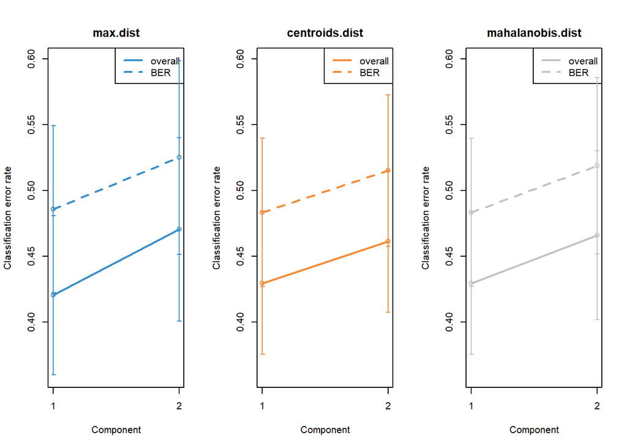

```r
res_perf <- perf(res_plsda, validation = 'Mfold', folds = 5,
                 progressBar = FALSE, nrepeat = 20)
plot(res_perf, overlay = 'measure', sd = TRUE)
```

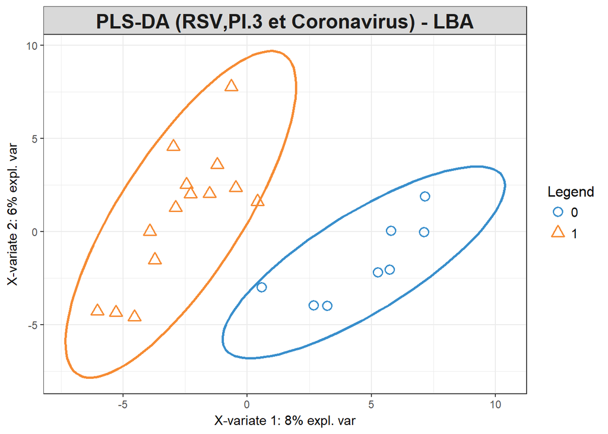

```r
plotIndiv(res_plsda , comp = c(1, 2), ind.names = FALSE, ellipse = TRUE,
          legend = TRUE, title = 'PLS-DA (RSV,PI.3 et Coronavirus) - LBA')
```

```r
set.seed(33)
res_plsda <- tune.splsda(X=clean_log_LBA,Y=group_virus_LBA,
                         ncomp = nlevels(group_virus_LBA),
                         test.keepX = 1:20, validation = 'Mfold',
                         folds = 10, dist = 'mahalanobis.dist', nrepeat = 10,
                         progressBar = F)
```

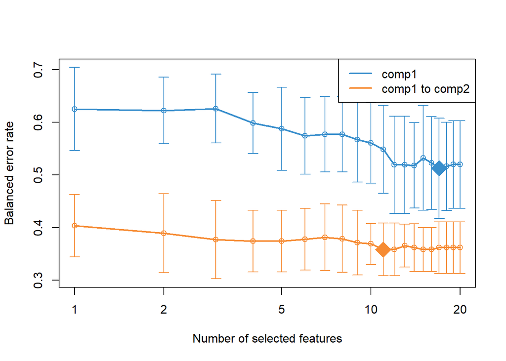

```r
plot(res_plsda)
```

```r
sel_keepX <- res_plsda$choice.keepX[1:2]
sel_keepX
```

```
## comp1 comp2
##    17    11
```

```r
res_splsda <- splsda(X=clean_log_LBA,Y=group_virus_LBA,
                     ncomp = nlevels(group_virus_LBA),
                     keepX = sel_keepX)
```

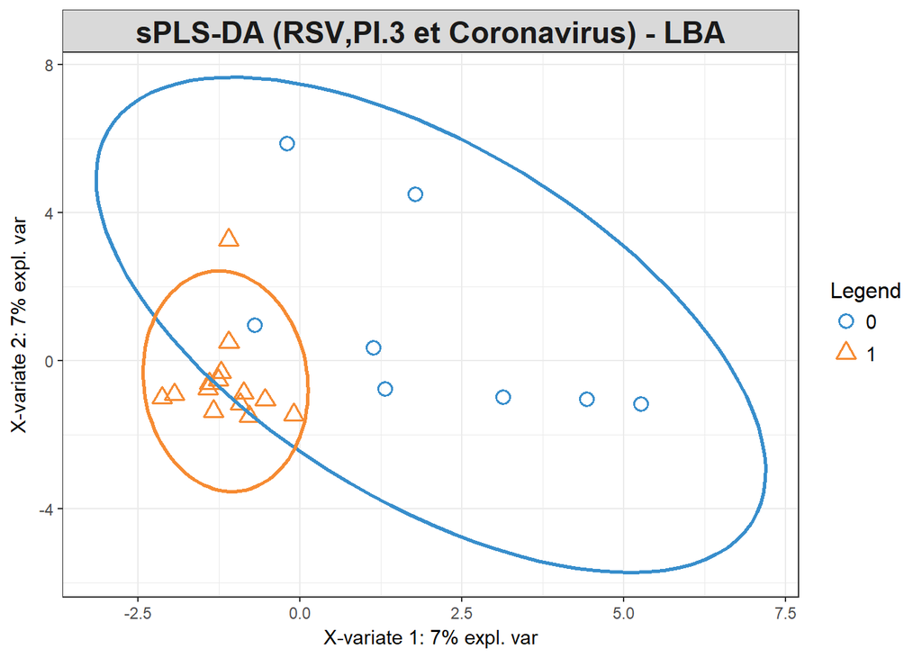

```r
plotIndiv(res_splsda, comp = c(1,2), ind.names = FALSE, ellipse = TRUE,
          legend = TRUE, title = 'sPLS-DA (RSV,PI.3 et Coronavirus) - LBA')
```

```r
test <- predict(res_splsda,clean_log_LBA)
pred <- test$class$mahalanobis.dist[,2]
get.confusion_matrix(group_virus_LBA,predicted=pred)
```

```
##   predicted.as.0 predicted.as.1
## 0              7              1
## 1              0             14
```

```r
table(group_virus_LBA)
```

```
## group_virus_LBA
##  0  1
##  8 14
```

```r
head(selectVar(res_splsda, comp = 1)$name)
```

```
## [1] "Paracoccus alcaliphilus"      "Psychrobacter pulmonis"
## [3] "Brachybacterium sp."          "Leptotrichiaceae"
## [5] "Jeotgalicoccus psychrophilus" "Delftia sp."
```

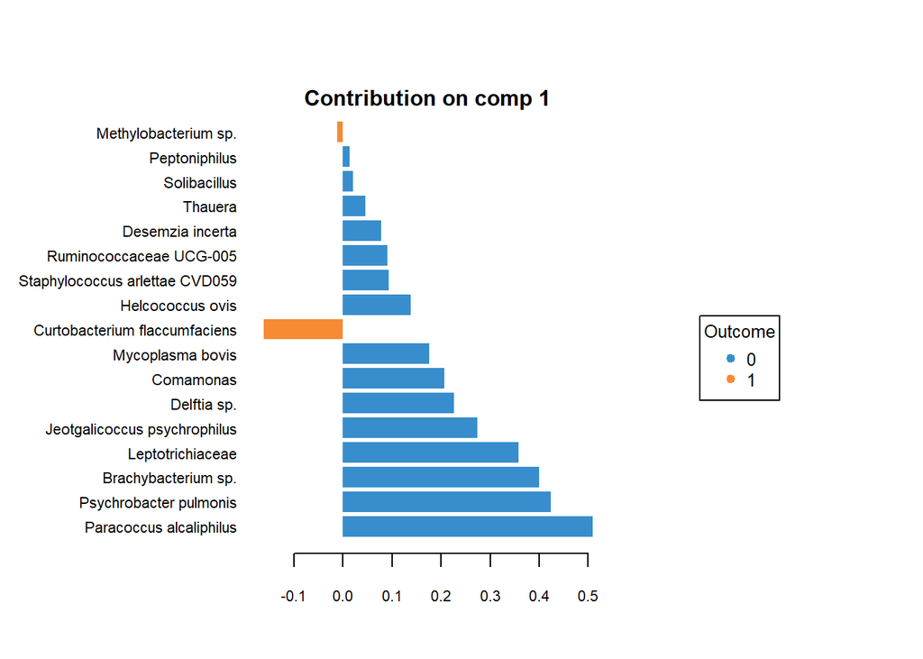

```r
plotLoadings(res_splsda, comp = 1, method = 'mean', contrib = 'max',
             size.title = 1)
```

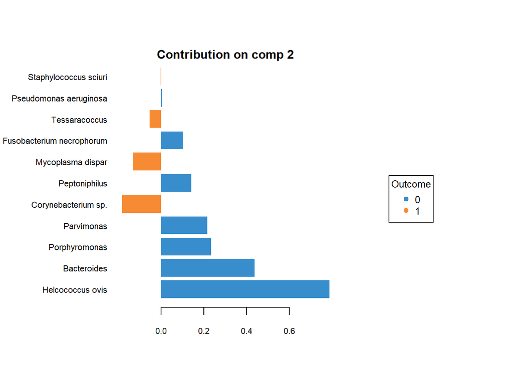

```r
plotLoadings(res_splsda, comp = 2, method = 'mean', contrib = 'max',
             size.title = 1)
```

**Presence vs Absence of viruses: Student tests**

```r
test0 <- clean_log[group_virus_LBA=="0",which(selectVar(res_splsda, comp = 1)$name[1]==species)]
test1 <- clean_log[group_virus_LBA=="1",which(selectVar(res_splsda, comp = 1)$name[1]==species)]
t.test(test0,test1)
```

```
##
##  Welch Two Sample t-test
##
## data:  test0 and test1
## t = 0.44295, df = 33.131, p-value = 0.6607
## alternative hypothesis: true difference in means is not equal to 0
## 95 percent confidence interval:
##  -0.9521709  1.4822678
## sample estimates:
## mean of x mean of y
##  1.760469  1.495421
```

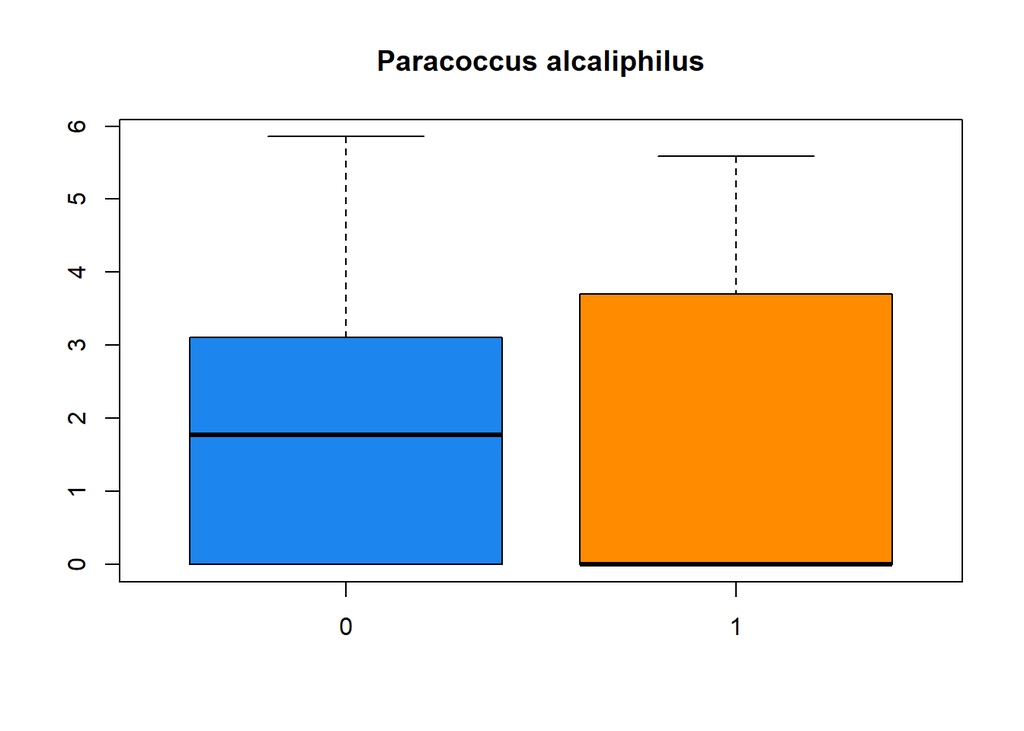

```r
boxplot(test0,test1,names=c("0","1"),
        main=selectVar(res_splsda, comp = 1)$name[1],col=c("dodgerblue2","darkorange"))
```

```r
test0 <- clean_log[group_virus_LBA=="0",which(selectVar(res_splsda, comp = 1)$name[2]==species)]
test1 <- clean_log[group_virus_LBA=="1",which(selectVar(res_splsda, comp = 1)$name[2]==species)]
t.test(test0,test1)
```

```
##
##  Welch Two Sample t-test
##
## data:  test0 and test1
## t = 2.2409, df = 19.028, p-value = 0.03716
## alternative hypothesis: true difference in means is not equal to 0
## 95 percent confidence interval:
##  0.113116 3.310445
## sample estimates:
## mean of x mean of y
## 2.6367155 0.9249348
```

We reject $H_0$ (the difference in means is equal to 0) hence we can say that the presence or not of these three viruses changes the values of the Psychrobacter pulmonis bateria. But the p-value is close to 0.05…

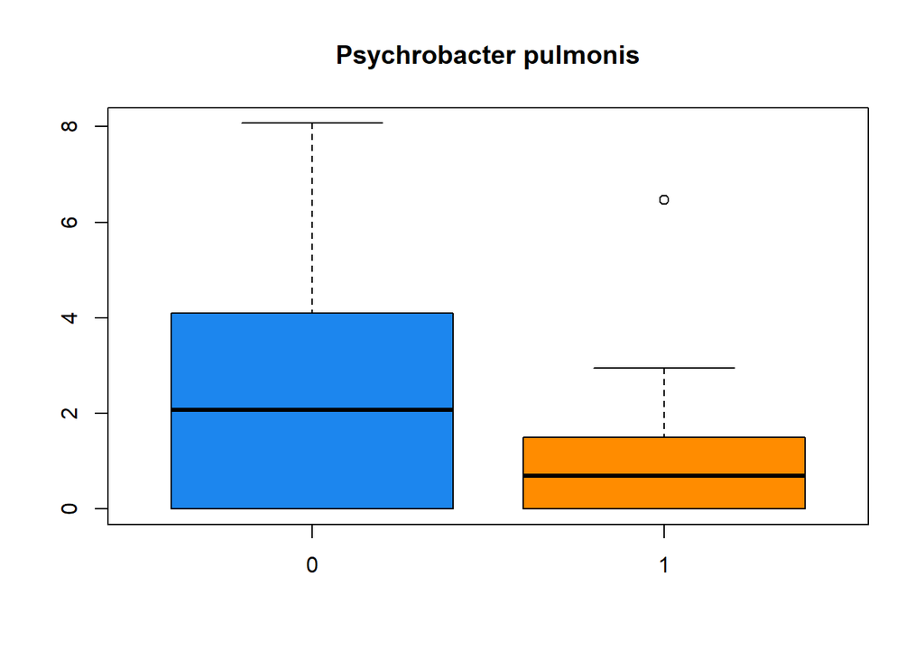

```r
boxplot(test0,test1,names=c("0","1"),
        main=selectVar(res_splsda, comp = 1)$name[2],col=c("dodgerblue2","darkorange"))
```

```r
#cim(res_splsda, row.sideColors = color.mixo(group_virus_LBA),row.names = clean_id_LBA)
```

## PLS-DA on `PI.3` - `EN` condition

```r
set.seed(11)
res_plsda <- plsda(X=clean_log_EN,Y=Y_EN$Ct.PI.3, ncomp = nlevels(Y_EN$Ct.PI.3))
res_perf <- perf(res_plsda, validation = 'Mfold', folds = 5,
                 progressBar = FALSE, nrepeat = 20)
```

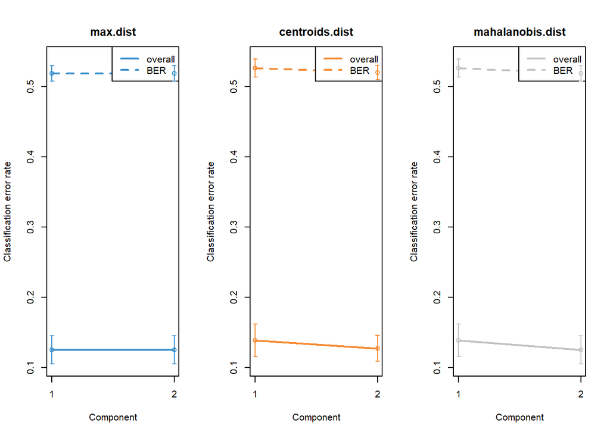

```r
plot(res_perf, overlay = 'measure', sd = TRUE)
```

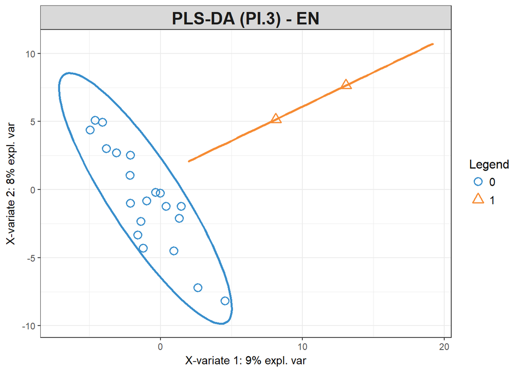

```r
plotIndiv(res_plsda , comp = c(1, 2), ind.names = FALSE, ellipse = TRUE,
          legend = TRUE, title = 'PLS-DA (PI.3) - EN')
```

```r
set.seed(33)
res_plsda <- tune.splsda(X=clean_log_EN,Y=Y_EN$Ct.PI.3,
                         ncomp = nlevels(Y_EN$Ct.PI.3),
                         test.keepX = 1:20, validation = 'Mfold',
                         folds = 10, dist = 'mahalanobis.dist', nrepeat = 10,
                         progressBar = F)

plot(res_plsda)

sel_keepX <- res_plsda$choice.keepX[1:2]
sel_keepX
```

**Error:** At least one class is not represented in one fold, which may unbalance the error rate.

```r
res_splsda <- splsda(X=clean_log_EN,Y=Y_EN$Ct.PI.3,
                     ncomp = nlevels(Y_EN$Ct.PI.3),
                     keepX = sel_keepX)

plotIndiv(res_splsda, comp = c(1,2), ind.names = FALSE, ellipse = TRUE,
          legend = TRUE, title = 'sPLS-DA (PI.3) - EN')
```

```r
head(selectVar(res_splsda, comp = 1)$name)
plotLoadings(res_splsda, comp = 1, method = 'mean', contrib = 'max',
             size.title = 1)
plotLoadings(res_splsda, comp = 2, method = 'mean', contrib = 'max',
             size.title = 1)
```

## PLS-DA on `PI.3` - `LBA` condition

```r
set.seed(11)
res_plsda <- plsda(X=clean_log_LBA,Y=Y_LBA$Ct.PI.3, ncomp = nlevels(Y_LBA$Ct.PI.3))
res_perf <- perf(res_plsda, validation = 'Mfold', folds = 5,
                 progressBar = FALSE, nrepeat = 20)
plot(res_perf, overlay = 'measure', sd = TRUE)
plotIndiv(res_plsda , comp = c(1, 2), ind.names = FALSE, ellipse = TRUE,
          legend = TRUE, title = 'PLS-DA (PI.3) - LBA')
```

**Error:** there is unbalanced class of `1`

```r
set.seed(33)
res_plsda <- tune.splsda(X=clean_log_LBA,Y=Y_LBA$Ct.PI.3,
                         ncomp = nlevels(Y_LBA$Ct.PI.3),
                         test.keepX = 1:20, validation = 'Mfold',
                         folds = 10, dist = 'mahalanobis.dist', nrepeat = 10,
                         progressBar = F)

plot(res_plsda)

sel_keepX <- res_plsda$choice.keepX[1:2]
sel_keepX
```

**Error:** there is unbalanced class of `1`

```r
res_splsda <- splsda(X=clean_log_LBA,Y=Y_LBA$Ct.PI.3,
                     ncomp = nlevels(Y_LBA$Ct.PI.3),
                     keepX = sel_keepX)

plotIndiv(res_splsda, comp = c(1,2), ind.names = FALSE, ellipse = TRUE,
          legend = TRUE, title = 'sPLS-DA (PI.3) - LBA')
```

```r
head(selectVar(res_splsda, comp = 1)$name)
plotLoadings(res_splsda, comp = 1, method = 'mean', contrib = 'max',
             size.title = 1)
plotLoadings(res_splsda, comp = 2, method = 'mean', contrib = 'max',
             size.title = 1)
```

### Random Forest on `group_virus` - `EN` condition:

```r
fit <- randomForest(group_virus_EN ~ ., data = X_EN,classwt=table(group_virus_EN), ntree=5000)
fit$confusion
```

```
##   0  1 class.error
## 0 1  8  0.88888889
## 1 1 12  0.07692308
```

### Random Forest on `group_virus` - `LBA` condition:

```r
fit <- randomForest(group_virus_LBA ~ ., data = X_LBA,classwt=table(group_virus_LBA), ntree=5000)
fit$confusion
```

```
##   0  1 class.error
## 0 0  8   1.0000000
## 1 2 12   0.1428571
```